# Get started with `epiprocess`

This package introduces a common data structure for epidemiological data sets measured over space and time, and offers associated utilities to perform basic signal processing tasks.

## Installing

This package is not on CRAN yet, so it can be installed using the [`devtools`](https://devtools.r-lib.org) package:

```r
devtools::install_github("cmu-delphi/epiprocess", ref = "main")
```

Building the vignettes, such as this getting started guide, takes a significant amount of time. They are not included in the package by default. If you want to include vignettes, then use this modified command:

```r
devtools::install_github("cmu-delphi/epiprocess",
  ref = "main",
  build_vignettes = TRUE, dependencies = TRUE
)
```

## Getting data into `epi_df` format

We’ll start by showing how to get data into `epi_df` format, which is just a tibble with a bit of special structure, and is the format assumed by all of the functions in the `epiprocess` package. An `epi_df` object has (at least) the following columns:

- `geo_value`: the geographic value associated with each row of measurements.
- `time_value`: the time value associated with each row of measurements.

```r
library(epidatr)
library(epiprocess)
library(dplyr)
library(withr)

cases <- pub_covidcast(
  source = "jhu-csse",
  signals = "confirmed_cumulative_num",
  geo_type = "state",
  time_type = "day",
  geo_values = "ca,fl,ny,tx",
  time_values = epirange(20200301, 20220131),
)

colnames(cases)
```

```
##  [1] "geo_value"           "signal"              "source"
##  [4] "geo_type"            "time_type"           "time_value"
##  [7] "direction"           "issue"               "lag"
## [10] "missing_value"       "missing_stderr"      "missing_sample_size"
## [13] "value"               "stderr"              "sample_size"
```

As we can see, a data frame returned by `epidatr::pub_covidcast()` has the columns required for an `epi_df` object (along with many others). We can use `as_epi_df()`, with specification of some relevant metadata, to bring the data frame into `epi_df` format.

```r
x <- as_epi_df(cases,
  geo_type = "state",
  time_type = "day",
  as_of = max(cases$issue)
) %>%
  select(geo_value, time_value, total_cases = value)

class(x)
```

```
## [1] "epi_df"     "tbl_df"     "tbl"        "data.frame"
```

```r
summary(x)
```

```
## An `epi_df` x, with metadata:
## * geo_type  = state
## * time_type = day
## * as_of     = 2023-03-10
## ----------
## * min time value              = 2020-03-01
## * max time value              = 2022-01-31
## * average rows per time value = 4
```

```r
head(x)
```

```
## An `epi_df` object, 6 x 3 with metadata:
## * geo_type  = state
## * time_type = day
## * as_of     = 2023-03-10
##
## # A tibble: 6 × 3
##   geo_value time_value total_cases
## * <chr>     <date>           <dbl>
## 1 ca        2020-03-01          19
## 2 fl        2020-03-01           0
## 3 ny        2020-03-01           0
## 4 tx        2020-03-01           0
## 5 ca        2020-03-02          23
## 6 fl        2020-03-02           1
```

```r
attributes(x)$metadata
```

```
## $geo_type
## [1] "state"
##
## $time_type
## [1] "day"
##
## $as_of
## [1] "2023-03-10"
##
## $other_keys
## character(0)
```

## Some details on metadata

In general, an `epi_df` object has the following fields in its metadata:

- `geo_type`: the type for the geo values.
- `time_type`: the type for the time values.
- `as_of`: the time value at which the given data were available.

Metadata for an `epi_df` object `x` can be accessed (and altered) via `attributes(x)$metadata`. The first two fields here, `geo_type` and `time_type`, are not currently used by any downstream functions in the `epiprocess` package, and serve only as useful bits of information to convey about the data set at hand. The last field here, `as_of`, is one of the most unique aspects of an `epi_df` object.

In brief, we can think of an `epi_df` object as a single snapshot of a data set that contains the most up-to-date values of some signals of interest, as of the time specified `as_of`. For example, if `as_of` is January 31, 2022, then the `epi_df` object has the most up-to-date version of the data available as of January 31, 2022. The `epiprocess` package also provides a companion data structure called `epi_archive`, which stores the full version history of a given data set. See the [archive vignette](https://cmu-delphi.github.io/epiprocess/articles/archive.html) for more.

If any of the `geo_type`, `time_type`, or `as_of` arguments are missing in a call to `as_epi_df()`, then this function will try to infer them from the passed object. Usually, `geo_type` and `time_type` can be inferred from the `geo_value` and `time_value` columns, respectively, but inferring the `as_of` field is not as easy. See the documentation for `as_epi_df()` more details.

```r
x <- as_epi_df(cases, as_of = as.Date("2024-03-20")) %>%
  select(geo_value, time_value, total_cases = value)

attributes(x)$metadata
```

```
## $geo_type
## [1] "state"
##
## $time_type
## [1] "day"
##
## $as_of
## [1] "2024-03-20"
##
## $other_keys
## character(0)
```

## Using additional key columns in `epi_df`

In the following examples we will show how to create an `epi_df` with additional keys.

### Converting a `tsibble` that has county code as an extra key

```r
ex1 <- tibble(
  geo_value = rep(c("ca", "fl", "pa"), each = 3),
  county_code = c(
    "06059", "06061", "06067",
    "12111", "12113", "12117",
    "42101", "42103", "42105"
  ),
  time_value = rep(seq(as.Date("2020-06-01"), as.Date("2020-06-03"), by = "day"), length.out = length(geo_value)),
  value = seq_along(geo_value) + 0.01 * withr::with_rng_version("3.0.0", withr::with_seed(42, length(geo_value)))
) %>%
  as_tsibble(index = time_value, key = c(geo_value, county_code))

ex1 <- as_epi_df(x = ex1, geo_type = "state", time_type = "day", as_of = "2020-06-03")
```

The metadata now includes `county_code` as an extra key.

```r
attr(ex1, "metadata")
```

```
## $geo_type
## [1] "state"
##
## $time_type
## [1] "day"
##
## $as_of
## [1] "2020-06-03"
##
## $other_keys
## [1] "county_code"
```

### Dealing with misspecified column names

`epi_df` requires there to be columns `geo_value` and `time_value`, if they do not exist then `as_epi_df()` throws an error.

```r
data.frame(
  # misnamed
  state = rep(c("ca", "fl", "pa"), each = 3),
  # extra key
  pol = rep(c("blue", "swing", "swing"), each = 3),
  # misnamed
  reported_date = rep(seq(as.Date("2020-06-01"), as.Date("2020-06-03"), by = "day"), length.out = length(geo_value)),
  value = seq_along(geo_value) + 0.01 * withr::with_rng_version("3.0.0", withr::with_seed(42, length(geo_value)))
) %>% as_epi_df(as_of = as.Date("2024-03-20"))
```

```
## Error in eval(expr, envir, enclos): object 'geo_value' not found
```

The columns can be renamed to match `epi_df` format. In the example below, notice there is also an additional key `pol`.

```r
ex2 <- tibble(
  # misnamed
  state = rep(c("ca", "fl", "pa"), each = 3),
  # extra key
  pol = rep(c("blue", "swing", "swing"), each = 3),
  # misnamed
  reported_date = rep(seq(as.Date("2020-06-01"), as.Date("2020-06-03"), by = "day"), length.out = length(state)),
  value = seq_along(state) + 0.01 * withr::with_rng_version("3.0.0", withr::with_seed(42, length(state)))
) %>% data.frame()

head(ex2)
```

```
##   state   pol reported_date value
## 1    ca  blue    2020-06-01  1.09
## 2    ca  blue    2020-06-02  2.09
## 3    ca  blue    2020-06-03  3.09
## 4    fl swing    2020-06-01  4.09
## 5    fl swing    2020-06-02  5.09
## 6    fl swing    2020-06-03  6.09
```

```r
ex2 <- ex2 %>%
  rename(geo_value = state, time_value = reported_date) %>%
  as_epi_df(
    geo_type = "state", as_of = "2020-06-03",
    additional_metadata = list(other_keys = "pol")
  )

attr(ex2, "metadata")
```

```
## $geo_type
## [1] "state"
##
## $time_type
## [1] "day"
##
## $as_of
## [1] "2020-06-03"
##
## $other_keys
## [1] "pol"
```

### Adding additional keys to an `epi_df` object

In the above examples, all the keys are added to objects that are not `epi_df` objects. We illustrate how to add keys to an `epi_df` object.

We use a toy data set included in `epiprocess` prepared using the `covidcast` library and are filtering to a single state for simplicity.

```r
ex3 <- jhu_csse_county_level_subset %>%
  filter(time_value > "2021-12-01", state_name == "Massachusetts") %>%
  slice_tail(n = 6)

attr(ex3, "metadata") # geo_type is county currently
```

```
## $geo_type
## [1] "county"
##
## $time_type
## [1] "day"
##
## $as_of
## [1] "2022-05-23 14:35:45 PDT"
```

Now we add `state` (MA) and `pol` as new columns to the data and as new keys to the metadata. Reminder that lower case state name abbreviations are what we would expect if this were a `geo_value` column.

```r
ex3 <- ex3 %>%
  as_tibble() %>% # needed to add the additional metadata
  mutate(
    state = rep(tolower("MA"), 6),
    pol = rep(c("blue", "swing", "swing"), each = 2)
  ) %>%
  as_epi_df(additional_metadata = list(other_keys = c("state", "pol")), as_of = as.Date("2024-03-20"))

attr(ex3, "metadata")
```

[output not shown]

Note that the two additional keys we added, `state` and `pol`, are specified as a character vector in the `other_keys` component of the `additional_metadata` list. They must be specified in this manner so that downstream actions on the `epi_df`, like model fitting and prediction, can recognize and use these keys.

Currently `other_keys` metadata in `epi_df` doesn’t impact `epi_slide()`, contrary to `other_keys` in `as_epi_archive` which affects how the update data is interpreted.

## Working with `epi_df` objects downstream

Data in `epi_df` format should be easy to work with downstream, since it is a very standard tabular data format; in the other vignettes, we’ll walk through some basic signal processing tasks using functions provided in the `epiprocess` package. Of course, we can also write custom code for other downstream uses, like plotting, which is pretty easy to do `ggplot2`.

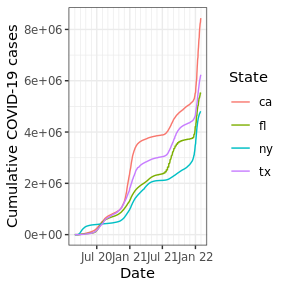

```r
library(ggplot2)
theme_set(theme_bw())

ggplot(x, aes(x = time_value, y = total_cases, color = geo_value)) +
  geom_line() +
  scale_x_date(minor_breaks = "month", date_labels = "%b %y") +
  labs(x = "Date", y = "Cumulative COVID-19 cases", color = "State")
```

As a last couple examples, we’ll look at some more data sets just to show how we might get them into `epi_df` format. Data on daily new (not cumulative) SARS cases in Canada in 2003, from the outbreaks package:

```r
x <- outbreaks::sars_canada_2003 %>%
  mutate(geo_value = "ca") %>%
  select(geo_value, time_value = date, starts_with("cases")) %>%
  as_epi_df(geo_type = "nation", as_of = as.Date("2024-03-20"))

head(x)
```

```
## An `epi_df` object, 6 x 6 with metadata:
## * geo_type  = nation
## * time_type = day
## * as_of     = 2024-03-20
##
## # A tibble: 6 × 6
##   geo_value time_value cases_travel cases_household cases_healthcare cases_other
## * <chr>     <date>            <int>           <int>            <int>       <int>
## 1 ca        2003-02-23            1               0                0           0
## 2 ca        2003-02-24            0               0                0           0
## 3 ca        2003-02-25            0               0                0           0
## 4 ca        2003-02-26            0               1                0           0
## 5 ca        2003-02-27            0               0                0           0
## 6 ca        2003-02-28            1               0                0           0
```

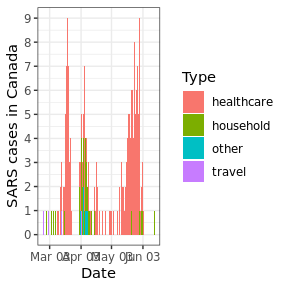

```r
library(tidyr)
x <- x %>%
  pivot_longer(starts_with("cases"), names_to = "type") %>%
  mutate(type = substring(type, 7))

yrange <- range(
  x %>%
    group_by(time_value) %>%
    summarize(value = sum(value)) %>%
    pull(value)
)

ggplot(x, aes(x = time_value, y = value)) +
  geom_col(aes(fill = type)) +
  scale_x_date(minor_breaks = "month", date_labels = "%b %y") +
  scale_y_continuous(breaks = yrange[1]:yrange[2]) +
  labs(x = "Date", y = "SARS cases in Canada", fill = "Type")
```

Data on new cases of Ebola in Sierra Leone in 2014, from the same package:

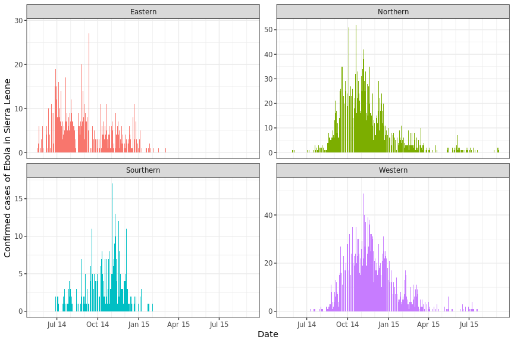

```r
x <- outbreaks::ebola_sierraleone_2014 %>%
  mutate(
    cases = ifelse(status == "confirmed", 1, 0),
    province = case_when(
      district %in% c("Kailahun", "Kenema", "Kono") ~ "Eastern",
      district %in% c(
        "Bombali", "Kambia", "Koinadugu",
        "Port Loko", "Tonkolili"
      ) ~ "Northern",
      district %in% c("Bo", "Bonthe", "Moyamba", "Pujehun") ~ "Sourthern",
      district %in% c("Western Rural", "Western Urban") ~ "Western"
    )
  ) %>%
  select(
    geo_value = province,
    time_value = date_of_onset,
    cases
  ) %>%
  filter(cases == 1) %>%
  group_by(geo_value, time_value) %>%
  summarise(cases = sum(cases)) %>%
  as_epi_df(geo_type = "province", as_of = as.Date("2024-03-20"))

ggplot(x, aes(x = time_value, y = cases)) +
  geom_col(aes(fill = geo_value), show.legend = FALSE) +
  facet_wrap(~geo_value, scales = "free_y") +
  scale_x_date(minor_breaks = "month", date_labels = "%b %y") +
  labs(x = "Date", y = "Confirmed cases of Ebola in Sierra Leone")
```

## Attribution

This document contains a dataset that is a modified part of the [COVID-19 Data Repository by the Center for Systems Science and Engineering (CSSE) at Johns Hopkins University](https://github.com/CSSEGISandData/COVID-19) as [republished in the COVIDcast Epidata API](https://cmu-delphi.github.io/delphi-epidata/api/covidcast-signals/jhu-csse.html). This data set is licensed under the terms of the [Creative Commons Attribution 4.0 International license](https://creativecommons.org/licenses/by/4.0/) by the Johns Hopkins University on behalf of its Center for Systems Science in Engineering. Copyright Johns Hopkins University 2020.

[From the COVIDcast Epidata API](https://cmu-delphi.github.io/delphi-epidata/api/covidcast-signals/jhu-csse.html): These signals are taken directly from the JHU CSSE [COVID-19 GitHub repository](https://github.com/CSSEGISandData/COVID-19) without changes.